# Assignment9

JWP

2019 6 21

## 다양한 표본분포와 중심극한정리

### 1. Chisqure

#### 1) 표본 크기의 변화에 따른 Chisqure 분포

```r
set.seed(9)
n <- 1000
chi.4.mean <- rep(NA, n)
chi.12.mean <- rep(NA, n)
chi.128.mean <- rep(NA, n)
chi.512.mean <- rep(NA, n)

for(i in 1:n) {
  chi.4.mean[i] <- mean(rchisq(4, df=1))
  chi.12.mean[i] <- mean(rchisq(12, df=1))
  chi.128.mean[i] <- mean(rchisq(128, df=1))
  chi.512.mean[i] <- mean(rchisq(512, df=1))
}
```

#### 표본평균들의 평균과 표준편차

```r
options(digits=4)
c(mean(chi.4.mean), sd(chi.4.mean))
```

```
## [1] 0.9447 0.6877
```

```r
c(mean(chi.12.mean), sd(chi.12.mean))
```

```
## [1] 0.9946 0.3936
```

```r
c(mean(chi.128.mean), sd(chi.128.mean))
```

```
## [1] 1.0038 0.1227
```

```r
c(mean(chi.512.mean), sd(chi.512.mean))
```

```
## [1] 1.0020 0.0627
```

#### Chi(df = k). mean: k, sd: sqrt(2*k/n)

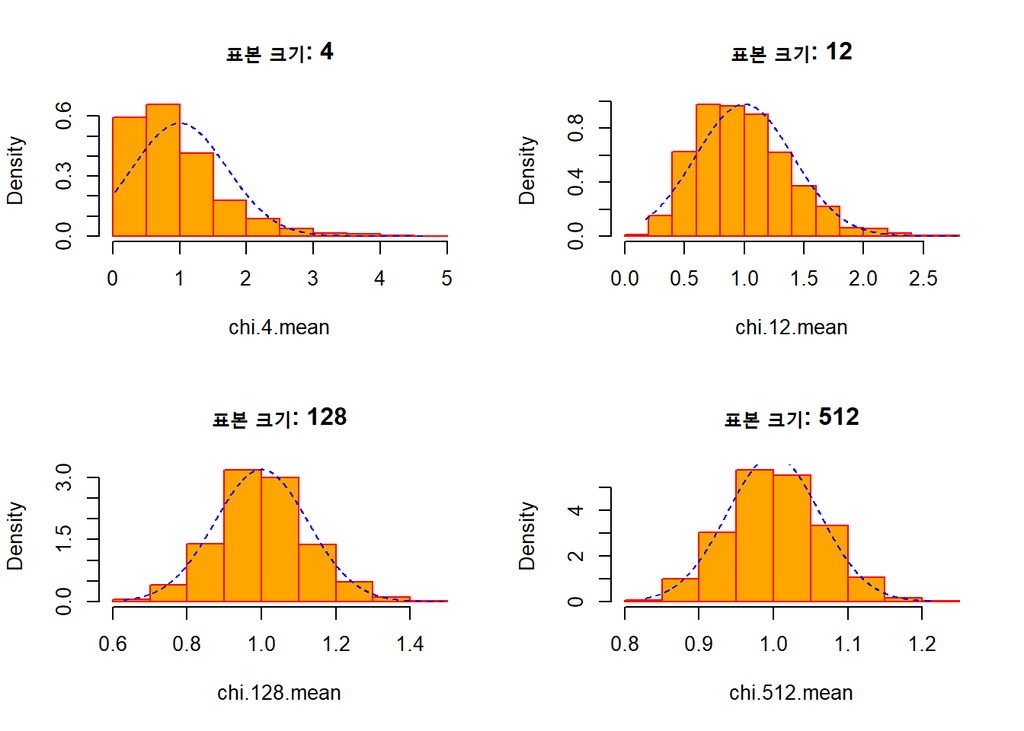

```r
par(mfrow=c(2,2))
hist(chi.4.mean, prob=TRUE, main="표본 크기: 4", col="orange", border="red")
x1 <- seq(min(chi.4.mean), max(chi.4.mean), length=1000)
y1 <- dnorm(x=x1, mean=1, sd=sqrt(2/4))
lines(x1, y1, lty=2, col="blue")

hist(chi.12.mean, prob=TRUE, main="표본 크기: 12", col="orange", border="red")
x2 <- seq(min(chi.12.mean), max(chi.12.mean), length=1000)
y2 <- dnorm(x=x2, mean=1, sd=sqrt(2/12))
lines(x2, y2, lty=2, col="blue")

hist(chi.128.mean, prob=TRUE, main="표본 크기: 128", col="orange", border="red")
x3 <- seq(min(chi.128.mean), max(chi.128.mean), length=1000)
y3 <- dnorm(x=x3, mean=1, sd=sqrt(2/128))
lines(x3, y3, lty=2, col="blue")

hist(chi.512.mean, prob=TRUE, main="표본 크기: 512", col="orange", border="red")
x4 <- seq(min(chi.512.mean), max(chi.512.mean), length=1000)
y4 <- dnorm(x=x4, mean=1, sd=sqrt(2/512))
lines(x4, y4, lty=2, col="blue")
```

#### 2) 자유도의 크기에 따른 Chisqure 분포 차이

```r
set.seed(9)
n <- 1000
chi.d1.mean <- rep(NA, n)
chi.d4.mean <- rep(NA, n)
chi.d16.mean <- rep(NA, n)
chi.d32.mean <- rep(NA, n)

rchisq(4, df=1)
```

```
## [1] 0.1377 0.1203 0.4278 0.2541
```

```r
for(i in 1:n) {
  chi.d1.mean[i] <- mean(rchisq(4, df=1))
  chi.d4.mean[i] <- mean(rchisq(4, df=4))
  chi.d16.mean[i] <- mean(rchisq(4, df=16))
  chi.d32.mean[i] <- mean(rchisq(4, df=32))
}
```

#### 표본평균들의 평균과 표준편차

```r
options(digits=4)
c(mean(chi.d1.mean), sd(chi.d1.mean))
```

```
## [1] 1.0176 0.6753
```

```r
c(mean(chi.d4.mean), sd(chi.d4.mean))
```

```
## [1] 4.016 1.432
```

```r
c(mean(chi.d16.mean), sd(chi.d16.mean))
```

```
## [1] 15.931  2.836
```

```r
c(mean(chi.d32.mean), sd(chi.d32.mean))
```

```
## [1] 32.153  3.951
```

#### Chi(df = k). mean: k, sd: sqrt(2*k/n)

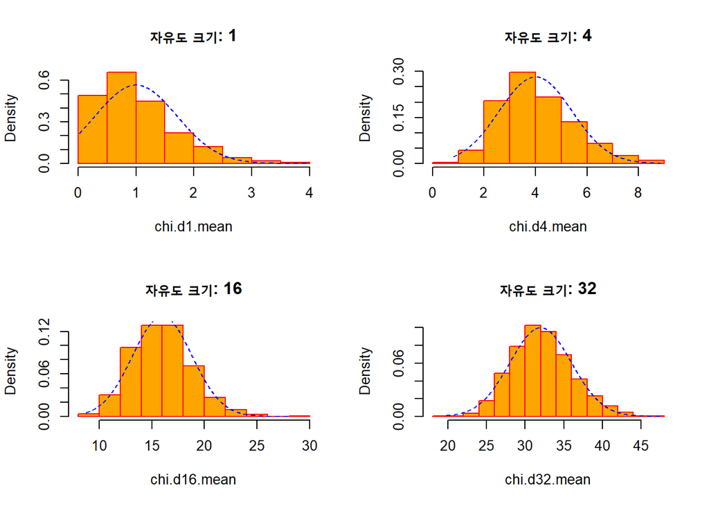

```r
par(mfrow=c(2,2))
hist(chi.d1.mean, prob=TRUE, main="자유도 크기: 1", col="orange", border="red")
x1 <- seq(min(chi.d1.mean), max(chi.d1.mean), length=1000)
y1 <- dnorm(x=x1, mean=1, sd=sqrt(2/4))
lines(x1, y1, lty=2, col="blue")

hist(chi.d4.mean, prob=TRUE, main="자유도 크기: 4", col="orange", border="red")
x2 <- seq(min(chi.d4.mean), max(chi.d4.mean), length=1000)
y2 <- dnorm(x=x2, mean=4, sd=sqrt(8/4))
lines(x2, y2, lty=2, col="blue")

hist(chi.d16.mean, prob=TRUE, main="자유도 크기: 16", col="orange", border="red")
x3 <- seq(min(chi.d16.mean), max(chi.d16.mean), length=1000)
y3 <- dnorm(x=x3, mean=16, sd=sqrt(32/4))
lines(x3, y3, lty=2, col="blue")

hist(chi.d32.mean, prob=TRUE, main="자유도 크기: 32", col="orange", border="red")
x4 <- seq(min(chi.d32.mean), max(chi.d32.mean), length=1000)
y4 <- dnorm(x=x4, mean=32, sd=sqrt(64/4))
lines(x4, y4, lty=2, col="blue")
```

#### 2. T

```r
n <- 1000
t.d4.mean <- rep(NA, n)
t.d16.mean <- rep(NA, n)
t.d32.mean <- rep(NA, n)
t.d64.mean <- rep(NA, n)

for(i in 1:n) {
  t.d4.mean[i] <- mean(rt(4, df=4))
  t.d16.mean[i] <- mean(rt(4, df=16))
  t.d32.mean[i] <- mean(rt(4, df=32))
  t.d64.mean[i] <- mean(rt(4, df=64))
}
```

#### 표본평균들의 평균과 표준편차

```r
options(digits=4)
c(mean(t.d4.mean), sd(t.d4.mean))
```

```
## [1] 0.02959 0.71806
```

```r
c(mean(t.d16.mean), sd(t.d16.mean))
```

```
## [1] -0.00285  0.52898
```

```r
c(mean(t.d32.mean), sd(t.d32.mean))
```

```
## [1] -0.01008  0.52264
```

```r
c(mean(t.d64.mean), sd(t.d64.mean))
```

```
## [1] -0.009596  0.501644
```

#### T(df = k). mean: 0, sd: sqrt((k/k-2)/n), k>2

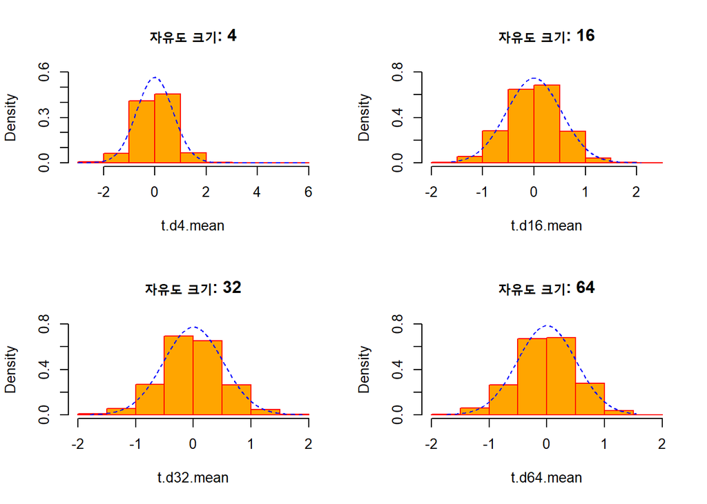

```r
par(mfrow=c(2,2))
hist(t.d4.mean, prob=TRUE, ylim=c(0,0.6), main="자유도 크기: 4", col="orange", border="red")
x1 <- seq(min(t.d4.mean), max(t.d4.mean), length=1000)
y1 <- dnorm(x=x1, mean=0, sd=sqrt(4/2/4))
lines(x1, y1, lty=2, col="blue")

hist(t.d16.mean, prob=TRUE, ylim=c(0,0.8), main="자유도 크기: 16", col="orange", border="red")
x2 <- seq(min(t.d16.mean), max(t.d16.mean), length=1000)
y2 <- dnorm(x=x2, mean=0, sd=sqrt(16/14/4))
lines(x2, y2, lty=2, col="blue")

hist(t.d32.mean, prob=TRUE, ylim=c(0,0.8), main="자유도 크기: 32", col="orange", border="red")
x3 <- seq(min(t.d32.mean), max(t.d32.mean), length=1000)
y3 <- dnorm(x=x3, mean=0, sd=sqrt(32/30/4))
lines(x3, y3, lty=2, col="blue")

hist(t.d64.mean, prob=TRUE, ylim=c(0,0.8), main="자유도 크기: 64", col="orange", border="red")
x4 <- seq(min(t.d64.mean), max(t.d64.mean), length=1000)
y4 <- dnorm(x=x4, mean=0, sd=sqrt(64/62/4))
lines(x4, y4, lty=2, col="blue")
```

#### 3. F

```r
set.seed(9)
n <- 1000
f.d5_d6.mean <- rep(NA, n)
f.d6_d10.mean <- rep(NA, n)
f.d10_d20.mean <- rep(NA, n)
f.d40_d45.mean <- rep(NA, n)

for(i in 1:n) {
  f.d5_d6.mean[i] <- mean(rf(4, df1=5, df2=6))
  f.d6_d10.mean[i] <- mean(rf(4, df1=6, df2=10))
  f.d10_d20.mean[i] <- mean(rf(4, df1=10, df2=20))
  f.d40_d45.mean[i] <- mean(rf(4, df1=40, df2=45))
}
```

#### 표본평균들의 평균과 표준편차

```r
options(digits=4)
c(mean(f.d5_d6.mean), sd(f.d5_d6.mean))
```

```
## [1] 1.549 1.027
```

```r
c(mean(f.d6_d10.mean), sd(f.d6_d10.mean))
```

```
## [1] 1.2149 0.5166
```

```r
c(mean(f.d10_d20.mean), sd(f.d10_d20.mean))
```

```
## [1] 1.0966 0.3111
```

```r
c(mean(f.d40_d45.mean), sd(f.d40_d45.mean))
```

```
## [1] 1.0512 0.1671
```

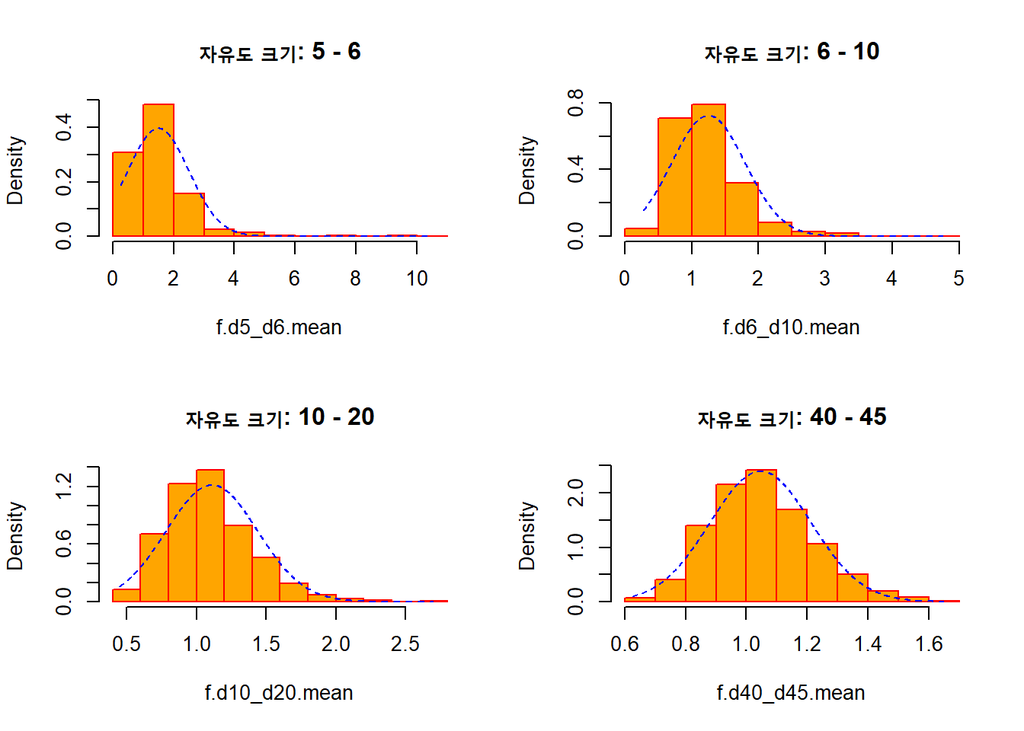

```r
num1 <- c(5,6,10,40)
num2 <- c(6,10,20,45)

fm <- c()
fsd <- c()
for(i in 1:4) {
  fm <- c(fm, num2[i]/(num2[i]-2))
  fsd <- c(fsd, sqrt(((2*(num2[i]^2)*(num1[i]+num2[i]-2))/(num1[i]*((num2[i]-2)^2)*(num2[i]-4)))/4))
}

par(mfrow=c(2,2))
hist(f.d5_d6.mean, prob=TRUE, main="자유도 크기: 5 - 6", col="orange", border="red")
x1 <- seq(min(f.d5_d6.mean), max(f.d5_d6.mean), length=1000)
y1 <- dnorm(x=x1, mean=fm[1], sd=fsd[1])
lines(x1, y1, lty=2, col="blue")

hist(f.d6_d10.mean, prob=TRUE, main="자유도 크기: 6 - 10", col="orange", border="red")
x2 <- seq(min(f.d6_d10.mean), max(f.d6_d10.mean), length=1000)
y2 <- dnorm(x=x2, mean=fm[2], sd=fsd[2])
lines(x2, y2, lty=2, col="blue")

hist(f.d10_d20.mean, prob=TRUE, main="자유도 크기: 10 - 20", col="orange", border="red")
x3 <- seq(min(f.d10_d20.mean), max(f.d10_d20.mean), length=1000)
y3 <- dnorm(x=x3, mean=fm[3], sd=fsd[3])
lines(x3, y3, lty=2, col="blue")

hist(f.d40_d45.mean, prob=TRUE, main="자유도 크기: 40 - 45", col="orange", border="red")
x4 <- seq(min(f.d40_d45.mean), max(f.d40_d45.mean), length=1000)
y4 <- dnorm(x=x4, mean=fm[4], sd=fsd[4])
lines(x4, y4, lty=2, col="blue")
```

## 정규분포 그래프

#### 1. A라는 전구회사에서 생산하는 전구의 수명은 800일이고 표준편차는 40일인 정규분포를 따른다고 한다. 이때 전구의 수명이 750일 이하일 확률을 구하시오.

```r
pnorm(750, 800, 40)
```

```
## [1] 0.1056
```

#### 그래프

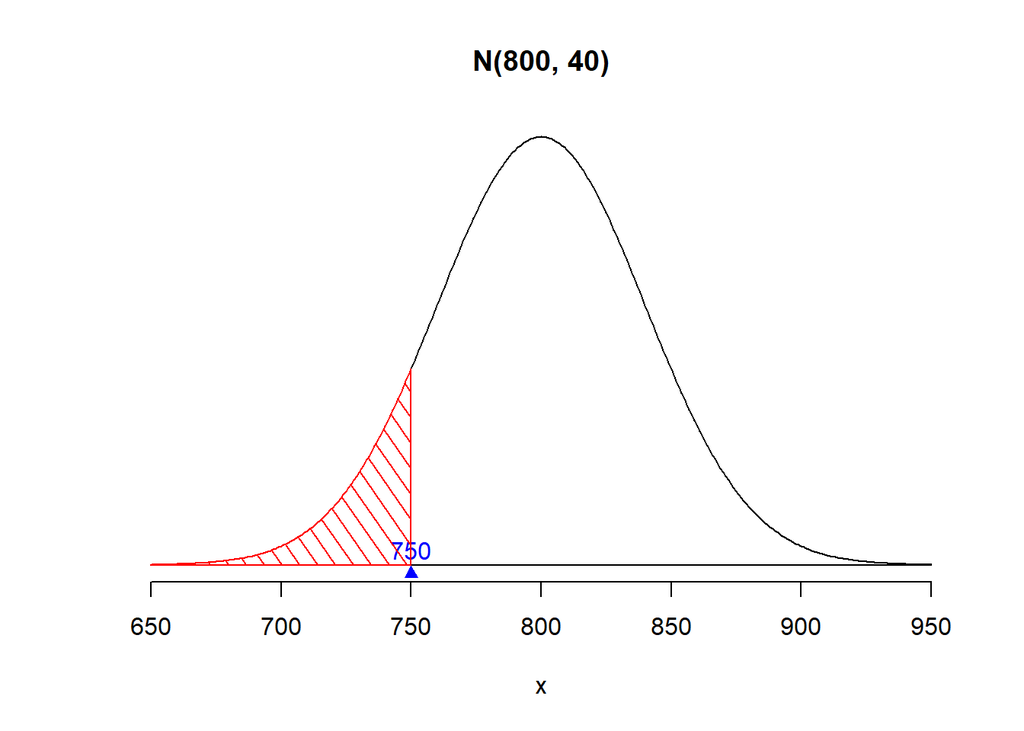

```r
x <- seq(650, 950, by=1)
x.p <- dnorm(x, 800, 40)
plot(x, x.p, axes=F, type="l", main="N(800, 40)", ylab="")
axis(1)

lines(c(650, 950), c(0, 0))
points(750, -0.0002, pch=17, col="blue")
text(750, 0.00035, "750", col="blue")

s <- seq(650, 750, by=1)
s.z <- dnorm(s, mean=800, sd=40)
s <- c(650, s, 750)
s.z <- c(0, s.z, 0)
polygon(s, s.z, col="red", density=10, angle=305)
```

#### 2. 어느 한 회사에 다니는 종업원들의 근무기간을 조사하였더니, 평균은 11년이고 분산이 16년인 정규분포를 따른다고 한다.

```r
mu <- 11
sigma <- 4
```

#### 1) 20년 이상 근무한 종업원의 비율을 구하시오.

```r
1-pnorm(20, mu, sigma)
```

```
## [1] 0.01222
```

#### 그래프

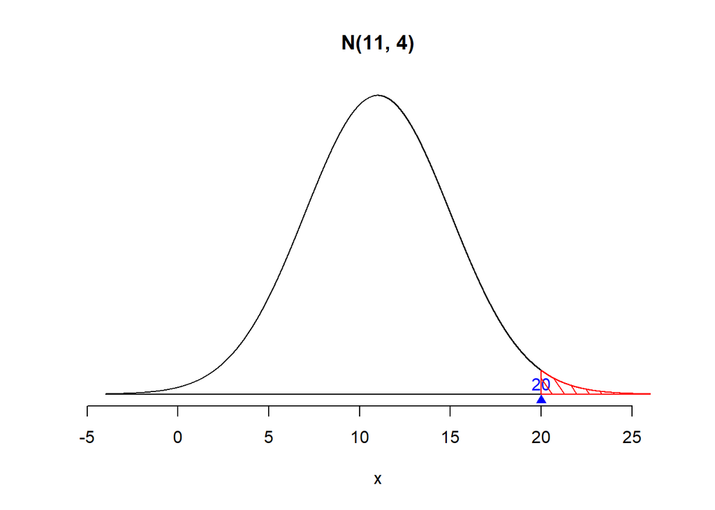

```r
x <- seq(-4, 26, by=0.001)
x.p <- dnorm(x, 11, 4)
plot(x, x.p, axes=F, type="l", main="N(11, 4)", ylab="")
axis(1)

lines(c(-4, 26), c(0, 0))
points(20, -0.002, pch=17, col="blue")
text(20, 0.0035, "20", col="blue")

s <- seq(20, 26, by=0.001)
s.z <- dnorm(s, mean=11, sd=4)
s <- c(20, s, 26)
s.z <- c(0, s.z, 0)
polygon(s, s.z, col="red", density=10, angle=305)
```

#### 2) 근무연수가 가장 오래된 10%의 종업원은 이 회사에서 몇 년 이상 근무했다고 볼 수 있는가?

```r
qnorm(0.9, mu, sigma)
```

```
## [1] 16.13
```

#### 3. 어느 고등학교 3학년 학생들의 수학성적은 평균이 70이고 표준편차가 8인 정규분포를 따른다고 한다. 이때 점수가 80점 이상이고 90점 이하인 학생의 비율을 구하시오.

```r
mu1 <- 70
sigma1 <- 8
pnorm(90, mu1, sigma1) - pnorm(80, mu1, sigma1)
```

```
## [1] 0.09944
```

#### 그래프

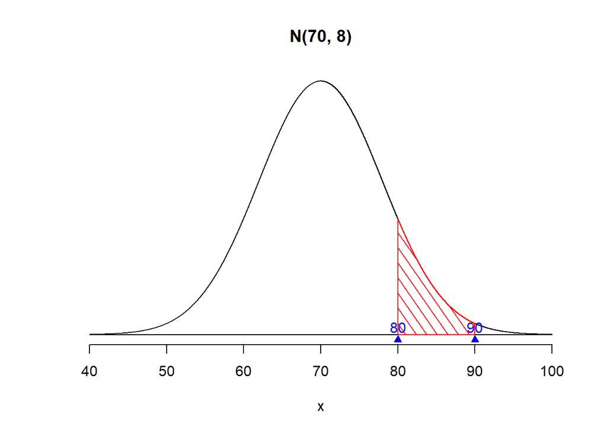

```r
x <- seq(40, 100, by=0.001)
x.p <- dnorm(x, 70, 8)
plot(x, x.p, axes=F, type="l", main="N(70, 8)", ylab="")
axis(1)

lines(c(40, 100), c(0, 0))
points(80, -0.001, pch=17, col="blue")
text(80, 0.0015, "80", col="blue")
points(90, -0.001, pch=17, col="blue")
text(90, 0.0015, "90", col="blue")

s <- seq(80, 90, by=0.001)
s.z <- dnorm(s, mean=70, sd=8)
s <- c(80, s, 90)
s.z <- c(0, s.z, 0)
polygon(s, s.z, col="red", density=10, angle=305)
```

#### 4. 확률변수 X가 평균이 1.5, 표준편차가 2인 정규분포를 따를 때, 실수 전체의 집합에서 정의된 함수 H(t)는 H(t) = P(t ≤ X ≤ t+1) 이다. H(0) + H(2)의 값을 구하시오.

```r
mu2 <- 1.5
sigma2 <- 2
H0 <- pnorm(1, mu2, sigma2) - pnorm(0, mu2, sigma2)       # H(0) = P(0 <= X <= 1)
H2 <- pnorm(3, mu2, sigma2) - pnorm(2, mu2, sigma2)       # H(2) = p(2 <= X <= 3)
H0 + H2
```

```
## [1] 0.3493
```

```r
H0*2
```

```
## [1] 0.3493
```

#### 그래프

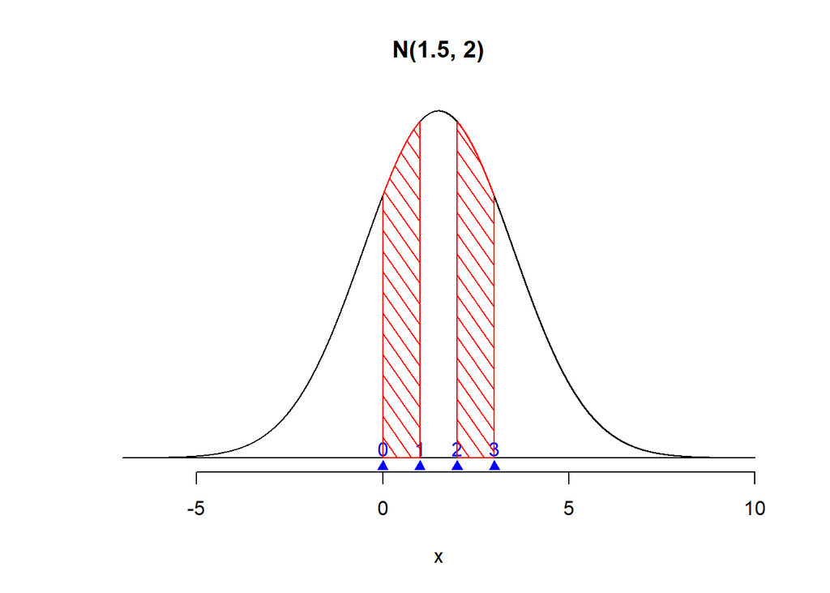

```r
x <- seq(-7, 10, by=0.001)
x.p <- dnorm(x, 1.5, 2)
plot(x, x.p, axes=F, type="l", main="N(1.5, 2)", ylab="")
axis(1)

lines(c(-7, 10), c(0, 0))
points(0, -0.005, pch=17, col="blue")
text(0, 0.0055, "0", col="blue")
points(1, -0.005, pch=17, col="blue")
text(1, 0.0055, "1", col="blue")
points(2, -0.005, pch=17, col="blue")
text(2, 0.0055, "2", col="blue")
points(3, -0.005, pch=17, col="blue")
text(3, 0.0055, "3", col="blue")

s <- seq(2, 3, by=0.001)
s.z <- dnorm(s, mean=1.5, sd=2)
s <- c(2, s, 3)
s.z <- c(0, s.z, 0)
polygon(s, s.z, col="red", density=10, angle=305)

s <- seq(0, 1, by=0.001)
s.z <- dnorm(s, mean=1.5, sd=2)
s <- c(0, s, 1)
s.z <- c(0, s.z, 0)
polygon(s, s.z, col="red", density=10, angle=305)
```